# The nuisance rate in eSVD2: what `master` did, what 1.1.0 did, and the cap of 1.2.0

Drafted by Claude for Kevin Z. Lin

2026-09-29

```r
library(ggplot2)
```

```r
out_dir <- "output"
.read <- function(file_name){
  utils::read.csv(file.path(out_dir, file_name))
}

discovery_df <- .read("summary_discovery.csv")
boundary_df <- .read("summary_boundary.csv")
accuracy_df <- .read("summary_accuracy.csv")
sweep_df <- .read("summary_cap_sweep.csv")
more_cells_df <- .read("summary_more_cells.csv")
variant_df <- .read("summary_deseq2_variants.csv")
null_scale_df <- .read("summary_null_scale.csv")
profile_df <- .read("report_profile_curves.csv")
rate_df <- .read("report_rates.csv")
pearson_df <- .read("report_pearson.csv")
by_rep_df <- .read("report_discovery_by_rep.csv")
qq_df <- .read("report_null_qq.csv")
rescale_df <- .read("report_rescaling.csv")
trend_third_df <- .read("report_trend_by_third.csv")
oracle_rate_df <- .read("report_oracle_by_rate.csv")
v120_by_rep_df <- .read("report_v120_by_rep.csv")
v120_agreement_df <- .read("report_v120_agreement.csv")

# The three versions this report is about, under the names the scripts use.
method_label_vec <- c(master = "master", mle = "devel", cap_10s = "10x cap")
method_col_vec <- c(master = "#2a78d6", devel = "#eb6834", `10x cap` = "#1baf7a")
.label_method <- function(candidate_vec){
  factor(method_label_vec[candidate_vec], levels = method_label_vec)
}

regime_vec <- c("null", "baseline", "weak_de", "low_count", "wide_rate",
                "trend", "near_poisson", "generate_null")

# One number out of a summary table, for the prose.
.get <- function(df, candidate, regime, column){
  val <- df[df$candidate == candidate & df$regime == regime, column]
  stopifnot(length(val) == 1)
  val
}
.fmt <- function(x, digits = 1){
  formatC(x, format = "f", digits = digits)
}

theme_set(theme_bw(base_size = 11))
theme_update(panel.grid.minor = element_blank(),
             strip.background = element_rect(fill = "#f1f0ec", colour = NA),
             legend.position = "bottom")
```

# 1 Overview

This report explains one decision about `eSVD2`: how to bound the per-gene nuisance rate that `estimate_nuisance()` returns. It was written to support the decision, and has been updated now that the decision is implemented. It builds on the comparison of `master` with `devel` (`../version_comparison/version_comparison_claude.html`) and on the brainstorm (`../OVERDISPERSION_BRAINSTORM.md`). The method is eSVD-DE (Lin, Qiu and Roeder 2024). The citations marked **wiki** are pages of the overdispersion wiki (location `OVERDISPERSION_WIKI`); each names the paper and the place in it that the wiki records.

**Status (2026-09-29).** Kevin chose the cap this report describes. It is implemented in `eSVD2` 1.2.0 (commit `1a0a536`) as `cap_multiplier = 10`. Section 5 gives the rule exactly as it ships, and what 1.2.0 adds around it. The evidence in sections 3 to 7 comes from a prototype that overwrote 1.1.0’s rate in the scripts of this folder. Section 5.2 shows that 1.2.0 itself reproduces the prototype’s discoveries exactly.

**Names in this report.** `devel` means version 1.1.0, whose rate is the uncapped maximum-likelihood estimate. `10x cap` is the rule shipped in 1.2.0. In `../version_comparison/`, `devel` is 1.2.0 and 1.1.0 is `devel_nocap`.

## 1.1 The short takeaway

1. **`master` did not estimate the rate for most genes.** Its search stopped at the gene’s largest library size and returned that bound as the answer. In the simulated regimes 78% to 100% of genes sat at the bound.
2. **`devel` removed the bound and returns the maximum-likelihood rate.** For most genes that estimate is accurate. For some genes the likelihood has no finite maximum, the rate runs to about $10^7$, the posterior collapses onto the fitted mean, and the test statistic inflates. Under the global null this gives 2.7 false discoveries per data set against `master`’s 0.2.
3. **The change, shipped in 1.2.0, is `devel`’s estimate capped at 10 times the gene’s median library size**: $\hat\beta_j^{\text{cap}} = \min\{\hat\beta_j^{\text{MLE}},\; 10 \cdot \text{median}_i\, s_{ji}\}$, with a gene that has no finite MLE set to the cap. (A floor, far below the cap, is in section 5.) In ordinary data about 11% of genes are capped; the rest keep their own estimate.
4. **It improves on `master` in two senses.** As an *estimate*, the capped rate is within twofold of the truth for 95% of genes against `master`’s 59%. As an input to the *test*, it gives the same false discoveries as `master` when the rate is unrelated to expression, and fewer false discoveries with more true discoveries when the rate depends on expression (1.0 and 21.7 against 2.3 and 20.7).
5. **It is not an improvement everywhere.** In nearly Poisson data no method estimates the rate. Genes whose true rate is above the cap are treated as more overdispersed than they are, which costs power on those genes.
6. **The cap is a device for calibrating this test, not a statement about biology.** A cap at the level of technical noise reported in the literature would be 5 to 10 times looser, and it does not calibrate the test.

All results are from simulation. No real data set has been run.

## 1.2 Plan of the report

| Section | Question | Main evidence |
| --- | --- | --- |
| 2 | What is the rate, and what does it do downstream? | formulas |
| 3 | What did `master` do? | likelihood curves; fraction of genes at the bound |
| 4 | What does `devel` do, and why does it inflate the test? | the boundary of the likelihood; the null scale of the statistic |
| 5 | What is the change as shipped in 1.2.0, and why 10? | the rule; 1.2.0 against the prototype; sweep of the cap |
| 6 | In what sense is it an improvement over `master`? | accuracy of the estimate; false and true discoveries |
| 7 | The nuances | units; large true rates; more cells; a real trend; the rescaling |
| 8 | What was decided, and what remains open |  |

## 1.3 How the numbers were produced

Every regime has 20 individuals (10 case, 10 control), 30 cells each, 300 genes and 10 replicates, drawn from the eSVD model unless stated. `devel` is fitted once per data set. Each version of the rate is then written over `nuisance_vec`, and `compute_posterior()`, `compute_test_statistic()` and `compute_pvalue()` are rerun. `master` is `master`’s own output (commit `3d5f7bf`, run in a separate process), fed through the same three steps.

| Regime | True rate $\beta_j$ (generator’s units) | DE genes | What it probes |
| --- | --- | --- | --- |
| `null` | 2 to 8 | 0 | calibration |
| `baseline` | 2 to 8 | 15, effect 0.8 | ordinary data |
| `weak_de` | 2 to 8 | 30, effect ±0.3 | power |
| `low_count` | 2 to 8 | 30, effect ±0.6 | mean counts of 0.1 to 0.6 |
| `wide_rate` | 0.5 to 200, unrelated to expression | 30, effect ±0.3 | very different rates between genes |
| `trend` | follows expression (section 7.4) | 30, effect ±0.5 | a real relation between overdispersion and expression |
| `near_poisson` | 50 to 1000 | 15, effect 0.8 | almost no overdispersion |
| `generate_null` | the package’s `generate_null()` | 10 | a generator not from the eSVD model |

`09_run_v120_claude.R` then fits every data set again with 1.2.0 itself, end to end, at its default cap. That is the check in section 5.2.

`run_all_claude.sh` reruns everything, including this report, in about 6 minutes. The dry-runs load 1.1.0 from `../version_comparison/lib/devel_1.1.0`, and the check loads 1.2.0 from `lib/devel`.

# 2 The rate, and what it does downstream

## 2.1 The model

For gene $j$ in cell $i$, with fitted mean $\mu_{ji}$ and fitted covariate-adjusted library size $s_{ji}$,

$$A_{ji} \mid \lambda_{ji} \sim \text{Poisson}(s_{ji}\,\lambda_{ji}),
\qquad
\lambda_{ji} \sim \text{Gamma}(\text{shape} = \mu_{ji}\beta_j,\
\text{rate} = \beta_j).$$

So $\mathbb{E}\,\lambda_{ji} = \mu_{ji}$ and $\text{Var}\,\lambda_{ji} = \mu_{ji}/\beta_j$. The package stores the **rate** $\beta_j$ in `nuisance_vec`. It is the reciprocal of the paper’s overdispersion $\gamma_j$. **A large $\beta_j$ means little overdispersion, and $\beta_j \to \infty$ is a Poisson gene.**

Integrating out $\lambda$, the count is negative binomial with mean $m_{ji} = \mu_{ji} s_{ji}$ and

$$\text{Var}(A_{ji}) = m_{ji}\left(1 + \frac{s_{ji}}{\beta_j}\right).$$

Three things follow from this one line.

- **The Fano factor is $1 + s_{ji}/\beta_j$.** The excess over Poisson is the ratio of the library size to the rate.
- **$\beta_j$ has the units of $s_{ji}$.** The two enter the likelihood only through $s_{ji} + \beta_j$. A rate means nothing until it is compared with the gene’s library size, so this report uses the **unit-free rate** $b_j = \beta_j / \text{median}_i\, s_{ji}$ throughout. A unit-free rate of 10 is a Fano factor of about 1.1.
- **In the usual form $\text{Var} = m + m^2/\theta$, the size is $\theta_{ji} = \mu_{ji}\beta_j$.** This is the translation to the parameterization of DESeq2, sctransform and the papers cited below (wiki: `dispersion-parameterizations`, whose canonical form is $\text{Var}(Y) = \mu + \alpha\mu^2$ with $\alpha = 1/\theta$).

## 2.2 The estimate

`gamma_rate()` maximizes, for each gene separately and with $\mu$ and $s$ fixed at their fitted values,

$$\ell_j(\beta) = \sum_i \Big[ \log\Gamma(\mu_{ji}\beta + A_{ji}) -
\log\Gamma(\mu_{ji}\beta)
+ \mu_{ji}\beta\,\log\frac{\beta}{s_{ji}+\beta} -
A_{ji}\log(s_{ji}+\beta) \Big] + \text{const}.$$

As $\beta \to \infty$ this tends to the Poisson log-likelihood $\sum_i [A_{ji}\log\mu_{ji} - \mu_{ji}s_{ji}] + \text{const}$. **The likelihood always has a finite limit on the right.** Whether it rises above that limit somewhere to the left decides whether a finite maximizer exists.

## 2.3 What the rate does downstream

The posterior of $\lambda_{ji}$ is $\text{Gamma}(A_{ji} + \mu_{ji}\beta_j,\ s_{ji} + \beta_j)$, with

$$\mathbb{E}[\lambda_{ji} \mid A_{ji}] = (1 -
w_{ji})\,\frac{A_{ji}}{s_{ji}} + w_{ji}\,\mu_{ji},
\qquad
w_{ji} = \frac{\beta_j}{s_{ji} + \beta_j},
\qquad
\text{Var}[\lambda_{ji} \mid A_{ji}] = \frac{A_{ji} +
\mu_{ji}\beta_j}{(s_{ji} + \beta_j)^2}.$$

**The rate is the weight of the fit against the data.** The test then averages within individuals ($m_{\text{ind}}$ for the posterior means, $\bar V_{\text{ind}}$ for the posterior variances) and forms, per arm,

$$v = \text{mean}_{\text{ind}}(\bar V_{\text{ind}}) +
\text{var}_{\text{ind}}(m_{\text{ind}}),
\qquad
T_j = \frac{\bar m_{\text{case}} - \bar
m_{\text{control}}}{\sqrt{v_{\text{case}}/n_1 +
v_{\text{control}}/n_0}}.$$

The first term of $v$ is 95% to 98% of it (`CLAUDE_kevin.md`). For large $\beta_j$ it behaves like $\mu/\beta_j$ and vanishes, while the numerator, a difference of fitted means that contain the fitted case-control coefficient, does not.

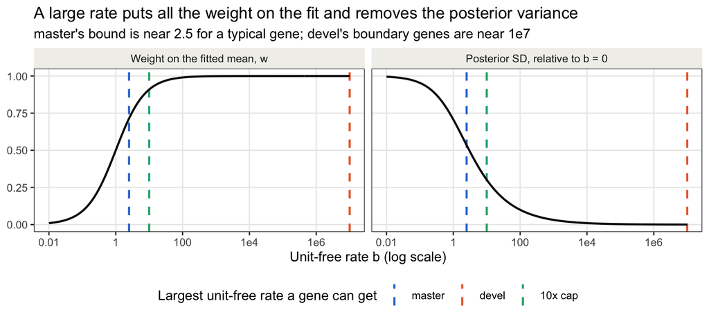

```r
b_vec <- 10^seq(-2, 7, length.out = 300)
# One cell with A = mu * s, so that the posterior mean is mu whatever b is.
curve_df <- rbind(
  data.frame(b = b_vec,
             value = b_vec / (1 + b_vec),
             quantity = "Weight on the fitted mean, w"),
  data.frame(b = b_vec,
             value = 1 / sqrt(1 + b_vec),
             quantity = "Posterior SD, relative to b = 0")
)
curve_df$quantity <- factor(curve_df$quantity,
                            levels = c("Weight on the fitted mean, w",
                                       "Posterior SD, relative to b = 0"))
mark_df <- data.frame(b = c(2.5, 10, 1e7),
                      version = factor(c("master", "10x cap", "devel"),
                                       levels = names(method_col_vec)))

plot1 <- ggplot2::ggplot(curve_df, ggplot2::aes(x = b, y = value))
plot1 <- plot1 + ggplot2::geom_vline(data = mark_df,
                                     ggplot2::aes(xintercept = b,
                                                  colour = version),
                                     linewidth = 0.8, linetype = "dashed")
plot1 <- plot1 + ggplot2::geom_line(colour = "#0b0b0b", linewidth = 0.8)
plot1 <- plot1 + ggplot2::facet_wrap(~ quantity, nrow = 1)
plot1 <- plot1 + ggplot2::scale_x_log10(breaks = 10^c(-2, 0, 2, 4, 6),
                                        labels = c("0.01", "1", "100", "1e4",
                                                   "1e6"))
plot1 <- plot1 + ggplot2::scale_colour_manual(values = method_col_vec,
                                              name = "Largest unit-free rate a gene can get")
plot1 <- plot1 + ggplot2::labs(x = "Unit-free rate b (log scale)", y = NULL,
                               title = "A large rate puts all the weight on the fit and removes the posterior variance",
                               subtitle = "master's bound is near 2.5 for a typical gene; devel's boundary genes are near 1e7")
plot(plot1)
```

## 2.4 The rescaling that follows

Before the posterior is computed, `compute_posterior()` applies `bool_stabilize_underdispersion`: **if the geometric mean of the rates exceeds 1, every rate is divided by it.** When that happens only the rates *relative to each other* reach the posterior. Section 7.5 shows where it happens and what it does to `devel`’s rates.

## 2.5 The three versions side by side

|  | `master` (`3d5f7bf`) | `devel` (1.1.0) | 1.2.0 (`1a0a536`) |
| --- | --- | --- | --- |
| Search for the root of $\ell_j'$ | Newton inside $[10^{-6},\ \max_i s_{ji}]$ | bracket grown by doubling until $\ell_j' \le 0$ | as `devel` |
| Returned when the root is above the bracket | the bracket’s end, $\max_i s_{ji}$ | the root | the root |
| Returned when there is no finite root | the bracket’s end | about $10^7$ | $10 \cdot \text{median}_i\, s_{ji}$ |
| Floor | $10^{-6}$ | `min_val` $= 10^{-4}$ | $10^{-4}\cdot\text{median}_i\, s_{ji}$ |
| In one line | $\min\{\hat\beta^{\text{MLE}},\ \max_i s_{ji}\}$ | $\hat\beta^{\text{MLE}}$ | $\min\{\hat\beta^{\text{MLE}},\ 10\cdot\text{median}_i\, s_{ji}\}$ |
| Where | `src/gamma_rate.cpp` | `src/gamma_rate.cpp` | R, `.apply_nuisance_cap()`, after `gamma_rate()` |

# 3 What `master` did

## 3.1 Four genes

The curves below are the log-likelihood of four genes of one `baseline` data set, each minus its own maximum. The dashed lines are what each version returns or allows.

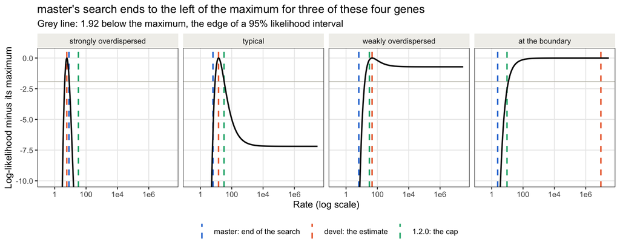

```r
example_levels <- c("strongly overdispersed", "typical",
                    "weakly overdispersed", "at the boundary")
profile_df$example <- factor(profile_df$example, levels = example_levels)
gene_df <- unique(profile_df[, c("example", "rate_mle", "legacy_cap",
                                 "proposed_cap")])
marker_df <- rbind(
  data.frame(example = gene_df$example, rate = gene_df$legacy_cap,
             marker = "master: end of the search"),
  data.frame(example = gene_df$example, rate = gene_df$rate_mle,
             marker = "devel: the estimate"),
  data.frame(example = gene_df$example, rate = gene_df$proposed_cap,
             marker = "1.2.0: the cap")
)
marker_levels <- c("master: end of the search", "devel: the estimate",
                   "1.2.0: the cap")
marker_df$marker <- factor(marker_df$marker, levels = marker_levels)
marker_col_vec <- stats::setNames(as.character(method_col_vec), marker_levels)

plot1 <- ggplot2::ggplot(profile_df, ggplot2::aes(x = rate, y = loglik_drop))
plot1 <- plot1 + ggplot2::geom_hline(yintercept = -stats::qchisq(0.95, df = 1) / 2,
                                     colour = "#c3c2b7", linewidth = 0.4)
plot1 <- plot1 + ggplot2::geom_vline(data = marker_df,
                                     ggplot2::aes(xintercept = rate,
                                                  colour = marker),
                                     linewidth = 0.8, linetype = "dashed")
plot1 <- plot1 + ggplot2::geom_line(colour = "#0b0b0b", linewidth = 0.8)
plot1 <- plot1 + ggplot2::facet_wrap(~ example, nrow = 1)
plot1 <- plot1 + ggplot2::scale_x_log10(breaks = 10^c(0, 2, 4, 6),
                                        labels = c("1", "100", "1e4", "1e6"))
plot1 <- plot1 + ggplot2::coord_cartesian(ylim = c(-10, 0.3))
plot1 <- plot1 + ggplot2::scale_colour_manual(values = marker_col_vec,
                                              name = NULL)
plot1 <- plot1 + ggplot2::labs(x = "Rate (log scale)",
                               y = "Log-likelihood minus its maximum",
                               title = "master's search ends to the left of the maximum for three of these four genes",
                               subtitle = "Grey line: 1.92 below the maximum, the edge of a 95% likelihood interval")
plot(plot1)
```

```r
example_df <- unique(profile_df[, c("example", "rate_mle", "legacy_cap",
                                    "proposed_cap", "rate_true_fit_units",
                                    "pearson")])
example_df$master_returns <- pmin(example_df$rate_mle, example_df$legacy_cap)
example_df$proposed_returns <- pmin(example_df$rate_mle,
                                    example_df$proposed_cap)
knitr::kable(example_df[, c("example", "rate_true_fit_units",
                            "master_returns", "rate_mle",
                            "proposed_returns", "pearson")],
             digits = c(0, 1, 1, 1, 1, 2), row.names = FALSE,
             col.names = c("Gene", "True rate (fit's units)",
                           "master returns", "devel returns",
                           "1.2.0 returns", "Pearson statistic"),
             caption = "The same four genes. The Pearson statistic is the mean of (count - fitted)^2 / fitted; below 1 means the residuals are less variable than Poisson.")
```

The same four genes. The Pearson statistic is the mean of (count - fitted)^2 / fitted; below 1 means the residuals are less variable than Poisson.

| Gene | True rate (fit’s units) | master returns | devel returns | 1.2.0 returns | Pearson statistic |
| --- | --- | --- | --- | --- | --- |
| strongly overdispersed | 6.9 | 5.9 | 5.9 | 5.9 | 1.59 |
| typical | 18.5 | 6.4 | 14.4 | 14.4 | 1.22 |
| weakly overdispersed | 20.5 | 6.6 | 46.0 | 30.8 | 1.06 |
| at the boundary | 6.8 | 2.4 | 9266200.0 | 9.5 | 0.97 |

Reading the four panels:

- **Strongly overdispersed.** The maximum is sharp and lies inside `master`’s search. All three versions return it.
- **Typical and weakly overdispersed.** The maximum exists, but to the right of `master`’s search. `master` returns the end of its search. `devel` and 1.2.0 return the maximum when it is below the cap, and 1.2.0 returns the cap otherwise.
- **At the boundary.** The curve rises all the way to the right and flattens. There is no finite maximum. `devel` returns a number near $10^7$, which is where its solver stops, and the likelihood is flat for four orders of magnitude to the left of it.

## 3.2 How many genes sat at `master`’s bound

```r
cap_df <- boundary_df[match(regime_vec, boundary_df$regime),
                      c("regime", "frac_at_legacy_cap")]
cap_df$master_spearman <- sapply(cap_df$regime, function(regime){
  val <- accuracy_df$spearman[accuracy_df$candidate == "master" &
                                accuracy_df$regime == regime]
  if(length(val) == 0) return(NA)
  val
})
knitr::kable(cap_df, digits = 2, row.names = FALSE,
             col.names = c("Regime",
                           "Genes whose devel estimate is above master's bound",
                           "Spearman of master's rate with the truth"),
             caption = "generate_null() has no per-gene truth in the model's terms, hence the NA.")
```

generate_null() has no per-gene truth in the model’s terms, hence the NA.

| Regime | Genes whose devel estimate is above master’s bound | Spearman of master’s rate with the truth |
| --- | --- | --- |
| null | 0.91 | 0.05 |
| baseline | 0.91 | 0.08 |
| weak_de | 0.92 | 0.02 |
| low_count | 0.92 | 0.02 |
| wide_rate | 0.78 | 0.46 |
| trend | 0.86 | -0.02 |
| near_poisson | 1.00 | -0.01 |
| generate_null | 0.39 | NA |

**For about nine genes in ten, `master`’s rate was the gene’s largest library size.** That is why its rates do not rank the genes by their true overdispersion. The bound also made every gene look more overdispersed than it is: `master`’s rates are a median of 0.57 times the truth in `baseline`.

This bound was what kept `master`’s test calibrated. Applying it to `devel`’s estimate, `pmin(devel, max library size)`, reproduces `master`’s rates to a median of 0.1% and its Welch statistics to within 0.025.

# 4 What `devel` does

## 4.1 The estimate is good for most genes, and infinite for some

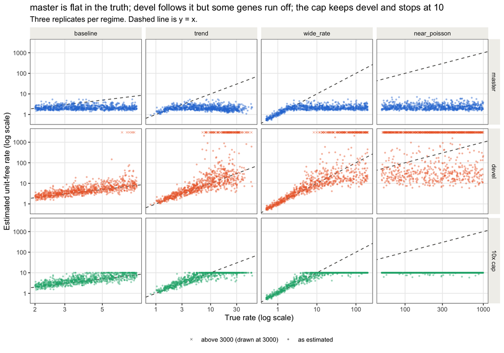

```r
plot_df <- rate_df[rate_df$regime %in% c("baseline", "trend", "wide_rate",
                                         "near_poisson"), ]
plot_df$method <- .label_method(plot_df$candidate)
plot_df$regime <- factor(plot_df$regime,
                         levels = c("baseline", "trend", "wide_rate",
                                    "near_poisson"))
clip_val <- 3000
plot_df$clipped <- ifelse(plot_df$rate_unit_free > clip_val,
                          "above 3000 (drawn at 3000)", "as estimated")
plot_df$rate_plot <- pmin(plot_df$rate_unit_free, clip_val)

plot1 <- ggplot2::ggplot(plot_df, ggplot2::aes(x = nuisance_true,
                                               y = rate_plot))
plot1 <- plot1 + ggplot2::geom_abline(slope = 1, intercept = 0,
                                      colour = "#52514e", linewidth = 0.5,
                                      linetype = "dashed")
plot1 <- plot1 + ggplot2::geom_point(ggplot2::aes(colour = method,
                                                  shape = clipped),
                                     size = 0.9, alpha = 0.45)
plot1 <- plot1 + ggplot2::facet_grid(method ~ regime, scales = "free_x")
plot1 <- plot1 + ggplot2::scale_x_log10()
plot1 <- plot1 + ggplot2::scale_y_log10()
plot1 <- plot1 + ggplot2::scale_colour_manual(values = method_col_vec,
                                              guide = "none")
plot1 <- plot1 + ggplot2::scale_shape_manual(values = c(`as estimated` = 16,
                                                        `above 3000 (drawn at 3000)` = 4),
                                             name = NULL)
plot1 <- plot1 + ggplot2::labs(x = "True rate (log scale)",
                               y = "Estimated unit-free rate (log scale)",
                               title = "master is flat in the truth; devel follows it but some genes run off; the cap keeps devel and stops at 10",
                               subtitle = "Three replicates per regime. Dashed line is y = x.")
plot(plot1)
```

```r
frac_df <- boundary_df[match(setdiff(regime_vec, "generate_null"),
                             boundary_df$regime),
                       c("regime", "frac_boundary", "pearson_boundary",
                         "pearson_interior", "ratio_unit_free",
                         "spearman_unit_free")]
knitr::kable(frac_df, digits = c(0, 3, 2, 2, 2, 2), row.names = FALSE,
             col.names = c("Regime", "Genes at the boundary",
                           "Pearson statistic, boundary genes",
                           "Pearson statistic, other genes",
                           "Median devel / truth, other genes",
                           "Spearman with the truth, other genes"),
             caption = "devel's estimate, all replicates. A gene is at the boundary when its Poisson log-likelihood is at least that of the returned rate.")
```

devel’s estimate, all replicates. A gene is at the boundary when its Poisson log-likelihood is at least that of the returned rate.

| Regime | Genes at the boundary | Pearson statistic, boundary genes | Pearson statistic, other genes | Median devel / truth, other genes | Spearman with the truth, other genes |
| --- | --- | --- | --- | --- | --- |
| null | 0.006 | 0.99 | 1.25 | 1.14 | 0.77 |
| baseline | 0.005 | 0.98 | 1.25 | 1.13 | 0.77 |
| weak_de | 0.004 | 0.97 | 1.25 | 1.12 | 0.78 |
| low_count | 0.025 | 0.95 | 1.18 | 1.39 | 0.64 |
| wide_rate | 0.160 | 0.95 | 1.35 | 1.03 | 0.88 |
| trend | 0.117 | 0.95 | 1.21 | 1.11 | 0.85 |
| near_poisson | 0.481 | 0.95 | 1.04 | 0.13 | 0.08 |

## 4.2 Why some genes have no finite estimate

**A gene is at the boundary when its residuals around the fit are no more variable than Poisson.** Expanding the log-likelihood of section 2.2 around its Poisson limit gives

$$\ell_j(\beta) = \ell_j^{\text{Poisson}} + \frac{D_j}{2\beta} +
O(\beta^{-2}),
\qquad
D_j = \sum_i \frac{(A_{ji} - m_{ji})^2 - A_{ji}}{\mu_{ji}},
\qquad m_{ji} = \mu_{ji}s_{ji}.$$

$D_j$ compares each squared residual with the count itself, which is what the squared residual would average if the gene were Poisson. When $D_j > 0$ the likelihood comes down to its limit from above, so a finite maximum exists. When $D_j < 0$ it climbs to the limit from below and never exceeds it.

```r
score_table_df <- as.data.frame(table(
  ifelse(pearson_df$score_at_poisson > 0, "D > 0", "D <= 0"),
  ifelse(pearson_df$bool_boundary, "at the boundary", "finite estimate")
))
colnames(score_table_df) <- c("Sign of D", "devel's estimate", "Genes")
knitr::kable(score_table_df, row.names = FALSE,
             caption = "The sign of D against what devel returned: baseline, low_count, trend and near_poisson, all replicates.")
```

The sign of D against what devel returned: baseline, low_count, trend and near_poisson, all replicates.

| Sign of D | devel’s estimate | Genes |
| --- | --- | --- |
| D <= 0 | at the boundary | 1885 |
| D > 0 | at the boundary | 2 |
| D <= 0 | finite estimate | 1 |
| D > 0 | finite estimate | 10112 |

The Pearson statistic (the mean of $(A - m)^2/m$, which is 1 for a Poisson gene) is the familiar version of the same comparison, and is plotted below.

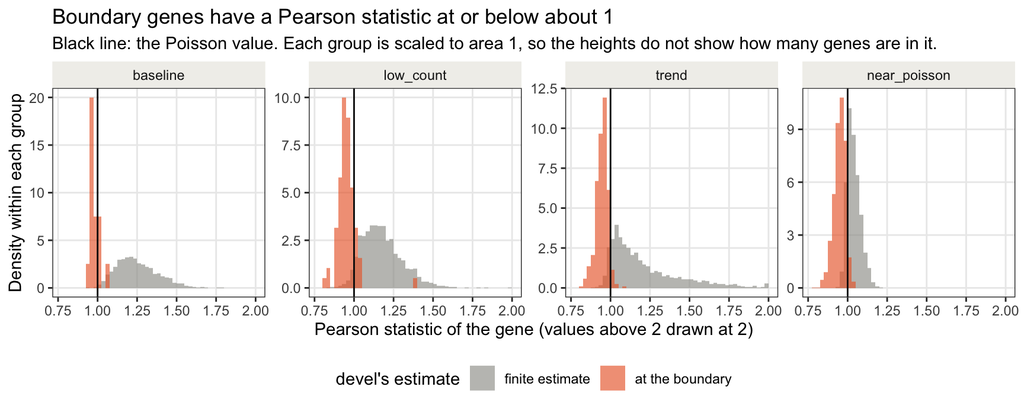

```r
plot_df <- pearson_df
plot_df$regime <- factor(plot_df$regime,
                         levels = c("baseline", "low_count", "trend",
                                    "near_poisson"))
plot_df$status <- factor(ifelse(plot_df$bool_boundary, "at the boundary",
                                "finite estimate"),
                         levels = c("finite estimate", "at the boundary"))
plot_df$pearson_plot <- pmin(plot_df$pearson, 2)

plot1 <- ggplot2::ggplot(plot_df, ggplot2::aes(x = pearson_plot))
plot1 <- plot1 + ggplot2::geom_histogram(ggplot2::aes(y = ggplot2::after_stat(density),
                                                      fill = status),
                                         position = "identity", alpha = 0.65,
                                         binwidth = 0.025, boundary = 1)
plot1 <- plot1 + ggplot2::geom_vline(xintercept = 1, colour = "#0b0b0b",
                                     linewidth = 0.5)
plot1 <- plot1 + ggplot2::facet_wrap(~ regime, nrow = 1, scales = "free_y")
plot1 <- plot1 + ggplot2::scale_fill_manual(values = c(`finite estimate` = "#9e9d97",
                                                       `at the boundary` = "#eb6834"),
                                            name = "devel's estimate")
plot1 <- plot1 + ggplot2::labs(x = "Pearson statistic of the gene (values above 2 drawn at 2)",
                               y = "Density within each group",
                               title = "Boundary genes have a Pearson statistic at or below about 1",
                               subtitle = "Black line: the Poisson value. Each group is scaled to area 1, so the heights do not show how many genes are in it.")
plot(plot1)
```

This is a known property of the negative binomial likelihood, not a fault of `devel`’s solver.

- *“the maximum likelihood (ML) estimator of κ, κ̂, does not have a distribution, since there exists a finite probability of observing a data set from which κ̂ may not be calculated. (This occurs when the sample mean exceeds the sample variance.)”* Piegorsch (1990), §1–2, p.863–864. (wiki: `piegorsch-1990`, `maximum-likelihood-dispersion`)
- *“if S² < Ȳ then the likelihood function reaches maximum at α = 0.”* Dai, Bao and Bao (2013), §1, p.22, under their Condition 1.1. (wiki: `dai-2012`) Here $\alpha = 0$ is $\beta = \infty$.
- It is common with little overdispersion and small means. In Piegorsch’s simulations at mean 1 and $\alpha = 1/5$, 570 of 1000 samples of size 10 and 267 of 1000 of size 50 had no positive estimate (Table 1, p.865; wiki: `underdispersion`).
- It has been seen in single-cell data. Refitting sctransform’s estimator on simulated counts with one true $\theta$, raising the iteration limit *“caused 49.9% of the estimates to diverge to infinity or above 10¹⁰”*. Lause, Berens and Kobak (2021), Results, p.5. (wiki: `lause-2021`) The `near_poisson` regime here gives 48%.
- The same paper names the conditions: *“estimation bias occurs especially for low NB means, small sample sizes, and large true values of θ […], i.e., for samples that are close to the Poisson distribution.”* (p.6)

**How to read a boundary estimate.** The wiki’s synthesis page `underdispersion` puts it this way: a gene at the boundary “should be read as *uninformative*, not as *Poisson*.” The data of such a gene are compatible with a wide range of rates (the flat part of the fourth panel above). `devel` picks the far end of that range.

## 4.3 Why that inflates the test

The empirical null fits one Gaussian to the statistics of all genes. **Its scale is about 0.3, because the variance in the Welch denominator is conservative, and the statistics of genes with a large rate are wider than that.**

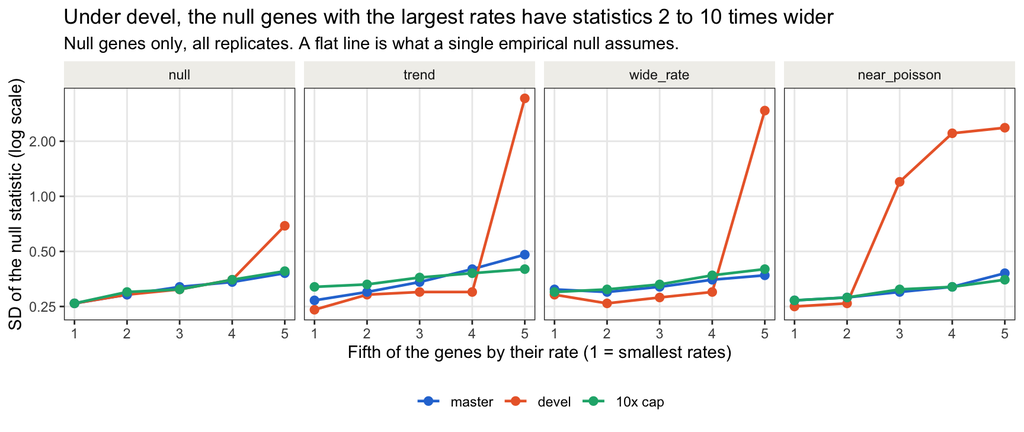

```r
plot_df <- null_scale_df[null_scale_df$candidate %in% names(method_label_vec) &
                           null_scale_df$regime %in% c("null", "trend",
                                                       "wide_rate",
                                                       "near_poisson"), ]
plot_df <- stats::reshape(plot_df, direction = "long",
                          varying = paste0("rate_group_", 1:5),
                          v.names = "null_sd", timevar = "fifth",
                          times = 1:5, idvar = c("candidate", "regime"))
plot_df$method <- .label_method(plot_df$candidate)
plot_df$regime <- factor(plot_df$regime,
                         levels = c("null", "trend", "wide_rate",
                                    "near_poisson"))

plot1 <- ggplot2::ggplot(plot_df, ggplot2::aes(x = fifth, y = null_sd,
                                               colour = method))
plot1 <- plot1 + ggplot2::geom_line(linewidth = 0.8)
plot1 <- plot1 + ggplot2::geom_point(size = 2.2)
plot1 <- plot1 + ggplot2::facet_wrap(~ regime, nrow = 1)
plot1 <- plot1 + ggplot2::scale_y_log10(breaks = c(0.25, 0.5, 1, 2, 4))
plot1 <- plot1 + ggplot2::scale_colour_manual(values = method_col_vec,
                                              name = NULL)
plot1 <- plot1 + ggplot2::labs(x = "Fifth of the genes by their rate (1 = smallest rates)",
                               y = "SD of the null statistic (log scale)",
                               title = "Under devel, the null genes with the largest rates have statistics 2 to 10 times wider",
                               subtitle = "Null genes only, all replicates. A flat line is what a single empirical null assumes.")
plot(plot1)
```

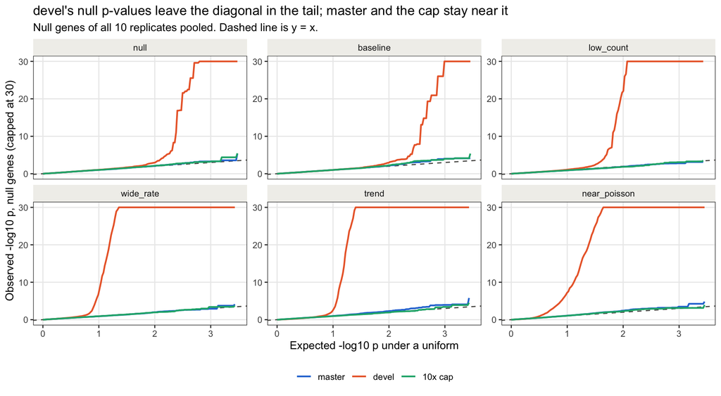

```r
plot_df <- qq_df[qq_df$regime %in% c("null", "baseline", "low_count",
                                     "wide_rate", "trend", "near_poisson"), ]
plot_df$method <- .label_method(plot_df$candidate)
plot_df$regime <- factor(plot_df$regime,
                         levels = c("null", "baseline", "low_count",
                                    "wide_rate", "trend", "near_poisson"))
# p-values below 1e-30 are drawn at 1e-30.
plot_df$observed_plot <- pmin(-log10(plot_df$observed), 30)

plot1 <- ggplot2::ggplot(plot_df, ggplot2::aes(x = -log10(expected),
                                               y = observed_plot,
                                               colour = method))
plot1 <- plot1 + ggplot2::geom_abline(slope = 1, intercept = 0,
                                      colour = "#52514e", linewidth = 0.5,
                                      linetype = "dashed")
plot1 <- plot1 + ggplot2::geom_line(linewidth = 0.8)
plot1 <- plot1 + ggplot2::facet_wrap(~ regime, nrow = 2, scales = "free_y")
plot1 <- plot1 + ggplot2::scale_colour_manual(values = method_col_vec,
                                              name = NULL)
plot1 <- plot1 + ggplot2::labs(x = "Expected -log10 p under a uniform",
                               y = "Observed -log10 p, null genes (capped at 30)",
                               title = "devel's null p-values leave the diagonal in the tail; master and the cap stay near it",
                               subtitle = "Null genes of all 10 replicates pooled. Dashed line is y = x.")
plot(plot1)
```

That the estimate of the dispersion decides the validity of the test is the point of two of the wiki’s sources.

- Svensson (2025), Introduction, p.2: *“accurate estimation of the φ parameter is crucial for statistical inference as SE(β̂) directly depends on φ.”* The same preprint found that the less efficient moment estimator gave the better tests: *“Surprisingly, the method of moments estimates lead to the best calibrated p values.”* (Results, p.3; wiki: `svensson-2025`)
- Law et al. (2014), Background, argue that negative-binomial methods treat the estimated dispersion as known, and that the resulting tests become liberal when the estimate is imprecise (wiki: `law-2014`; the wiki’s record of this passage has reconstructed words, so it is paraphrased here).

The wiki’s synthesis (`test-calibration-and-dispersion`) draws the conclusion that applies here: a dispersion estimate that is “biased but stable can produce better-calibrated tests than one that is unbiased but noisy.”

# 5 The change, as shipped in 1.2.0

## 5.1 The rule

For gene $j$, with $m_j = \text{median}_i\, s_{ji}$ the median over cells of the library the fit uses:

$$\hat\beta_j = \max\Big\{\min\big\{\hat\beta_j^{\text{MLE}},\ c \cdot
m_j\big\},\ \texttt{min\_val} \cdot m_j\Big\},
\qquad c = \texttt{cap\_multiplier} = 10,\quad \texttt{min\_val} =
10^{-4}.$$

Three choices are in the cap.

- **The cap is in units of the gene’s library size**, because the rate is (section 2.1). A cap at one number for all genes would be tight for highly expressed genes and loose for lowly expressed ones.
- **The median, not `master`’s maximum.** The maximum is set by one cell. So `cap_multiplier = 1` is close to `master`’s bound but not equal to it, and 1.2.0 does not offer `master`’s bound as an option.
- **Applied in R after `gamma_rate()`**, in the one function `.apply_nuisance_cap()`, so that `gamma_rate()` stays a maximum-likelihood estimator and its tests (T-CPP-GAM-05 and the others) keep their meaning.

Three more details were settled while implementing it; Kevin confirmed all three on 2026-09-29.

- **A gene with no finite MLE is set to the cap itself.** It is not set to the smaller of the cap and the value where the optimizer stopped. That value is arbitrary: about $10^7$ on one route, exactly $e^{10} = 22026$ on the log route. It lies below the cap once $m_j$ is above about 2200, which is the usual case when the library excludes the gene intercept (`bool_library_includes_interept = FALSE`). Such a gene is recognized by the statistic of section 4.2, $D_j = \sum_i [(A_{ji} - m_{ji})^2 - A_{ji}] / \mu_{ji} \le 0$.
- **The floor is in the units of the cap**, $\texttt{min\_val} \cdot m_j$, and `min_val` must be below `cap_multiplier`. So no gene can end above its cap. The absolute floor of 1.1.0 had held a gene with a degenerate fit ($m_j$ near $10^{-8}$) thousands of times above its cap.
- **An object built with `bool_diet = TRUE` keeps no covariates**, to stay small. Redoing its test at another cap needs the Seurat object it was built from (section 5.3).

`cap_multiplier = Inf` gives the rates of 1.1.0.

## 5.2 1.2.0 against the prototype

The numbers in sections 3 to 7 come from a prototype. It fitted 1.1.0 once, then wrote $\min\{\hat\beta^{\text{MLE}}_j,\ 10\, m_j\}$ over `nuisance_vec` before the posterior. `09_run_v120_claude.R` instead fits every data set with 1.2.0 itself, end to end, with no override.

```r
proto_df <- by_rep_df[by_rep_df$candidate == "cap_10s", ]
proto_sum_df <- stats::aggregate(cbind(fp, tp) ~ regime, data = proto_df,
                                 FUN = mean)
colnames(proto_sum_df)[2:3] <- c("fp_proto", "tp_proto")
v120_sum_df <- stats::aggregate(cbind(fp, tp, num_capped, num_boundary) ~ regime,
                                data = v120_by_rep_df, FUN = mean)
v120_table_df <- merge(v120_sum_df, proto_sum_df, by = "regime", all.x = TRUE)
v120_table_df <- merge(v120_table_df,
                       v120_agreement_df[, c("regime", "frac_rate_within_1pct",
                                             "num_fdr_calls_differ")],
                       by = "regime")
v120_table_df$frac_capped <- v120_table_df$num_capped / 300
v120_table_df$frac_boundary <- v120_table_df$num_boundary / 300
v120_order_vec <- c(regime_vec, setdiff(v120_table_df$regime, regime_vec))
v120_table_df <- v120_table_df[order(match(v120_table_df$regime,
                                           v120_order_vec)), ]
knitr::kable(v120_table_df[, c("regime", "fp", "fp_proto", "tp", "tp_proto",
                               "frac_capped", "frac_boundary",
                               "frac_rate_within_1pct",
                               "num_fdr_calls_differ")],
             digits = c(0, 1, 1, 1, 1, 3, 3, 4, 0), row.names = FALSE,
             col.names = c("Regime", "False disc., 1.2.0", "False disc., prototype",
                           "True disc., 1.2.0", "True disc., prototype",
                           "Capped (incl. boundary)", "Boundary",
                           "Rates within 1% of prototype",
                           "Genes called differently"),
             caption = "1.2.0 at cap_multiplier = 10 against the prototype, per data set (means of 10 replicates of 300 genes). The prototype's discovery counts were tabulated for eight regimes only; the last two columns compare gene by gene in all ten.")
```

1.2.0 at cap_multiplier = 10 against the prototype, per data set (means of 10 replicates of 300 genes). The prototype’s discovery counts were tabulated for eight regimes only; the last two columns compare gene by gene in all ten.

| Regime | False disc., 1.2.0 | False disc., prototype | True disc., 1.2.0 | True disc., prototype | Capped (incl. boundary) | Boundary | Rates within 1% of prototype | Genes called differently |
| --- | --- | --- | --- | --- | --- | --- | --- | --- |
| null | 0.2 | 0.2 | 0.0 | 0.0 | 0.115 | 0.006 | 1.0000 | 0 |
| baseline | 2.1 | 2.1 | 15.0 | 15.0 | 0.114 | 0.006 | 1.0000 | 0 |
| weak_de | 1.2 | 1.2 | 17.9 | 17.9 | 0.112 | 0.004 | 1.0000 | 0 |
| low_count | 0.6 | 0.6 | 11.9 | 11.9 | 0.225 | 0.025 | 1.0000 | 0 |
| wide_rate | 1.0 | 1.0 | 18.6 | 18.6 | 0.493 | 0.159 | 1.0000 | 0 |
| trend | 1.0 | 1.0 | 21.7 | 21.7 | 0.453 | 0.117 | 1.0000 | 0 |
| near_poisson | 1.8 | 1.8 | 15.0 | 15.0 | 0.955 | 0.481 | 1.0000 | 0 |
| generate_null | 0.1 | 0.1 | 8.1 | 8.1 | 0.072 | 0.008 | 0.9993 | 0 |
| minimal_design | 1.6 | NA | 15.0 | NA | 0.092 | 0.004 | 1.0000 | 0 |
| strong_de | 1.1 | NA | 14.7 | NA | 0.118 | 0.005 | 1.0000 | 0 |

**1.2.0 calls every gene of every data set as the prototype did**, and its rates agree with the prototype’s to within 1% for all genes but 2. Those are genes in `generate_null` where the old absolute floor had lifted the MLE and the new floor does not; their statistics did not move. The boundary rule made no difference here. A gene’s median library size in these fits is at most about 8 (in the regimes of `report_rates.csv`), so its cap is under 100. That is far below both of the optimizer’s stopping values, the smaller of which is 22026. Every result in this report is therefore a result about the shipped code.

## 5.3 What 1.2.0 adds around the cap

- **A status for every gene**, the factor `nuisance_status`. The precedence is:
  - `failed`: both estimation routes failed, and the gene gets the floor;
  - `boundary`: $D_j \le 0$;
  - `capped`: a finite MLE above the cap;
  - `estimated`: everything else.

  A gene lifted by the floor keeps `estimated`. The status is also the seventh column of `report_results()`.
- **What the fit stores beside `nuisance_vec`**: `nuisance_mle_vec` (the rate before the cap), `nuisance_library_median_vec` ($m_j$), and each gene’s mean count and sparsity. `param` records the multiplier, the floor, and the counts `nuisance_num_capped` (every gene the cap replaced, boundary genes included) and `nuisance_num_boundary`.
- **`recompute_pvalue(input_obj, cap_multiplier, seurat_obj = NULL)`**. It applies another cap to the stored MLE and repeats the posterior, the test statistic and the p-values with the settings in `param`, without fitting again. For a `bool_diet = TRUE` object it rebuilds the counts and covariates from the Seurat object, then checks them against summaries recorded at the fit: gene means, column sums, and sums weighted by position over cells, so that an exchange between cells is noticed.
- **`plot_nuisance()`** draws $\hat\beta_j / m_j$ on a log axis, with the cap as a line at $c$, against mean count, $-\log_{10}$ p-value or sparsity. **`plot_fitted_vs_observed()`** draws the fitted against the observed count, marking the pairs more than `num_sd` model standard deviations $\sqrt{m(1 + s/\beta)}$ from the fit.

**Every gene’s results move, not only the capped ones.** The rescaling of section 7.5 divides every rate by their geometric mean, which the cap lowers, and the empirical null is fitted to all genes. `NEWS.md` says so. And in the posterior, the cap is effectively tighter than $c$ for a gene whose library is below `library_min = 0.1`, because `compute_posterior()` floors the library there.

## 5.4 Why 10

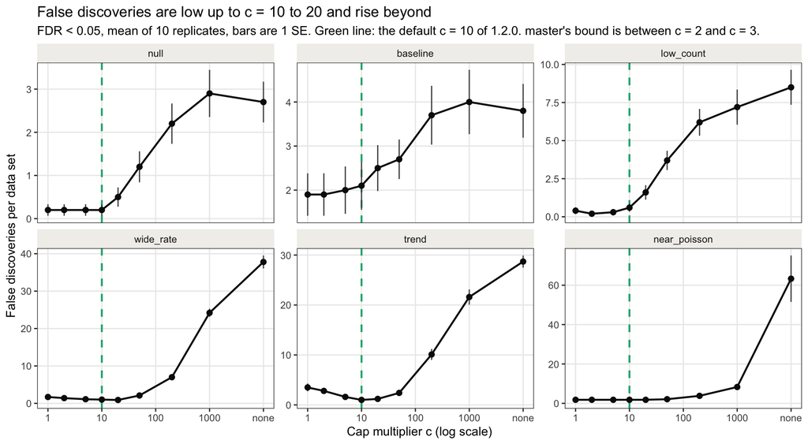

```r
sweep_plot_df <- sweep_df[grepl("^cap_", sweep_df$candidate), ]
sweep_plot_df$multiplier <- as.numeric(sub("^cap_", "",
                                           sweep_plot_df$candidate))
# "No cap" is drawn at 1e4 on the axis.
sweep_plot_df$multiplier_plot <- ifelse(is.finite(sweep_plot_df$multiplier),
                                        sweep_plot_df$multiplier, 1e4)
fp_regime_vec <- c("null", "baseline", "low_count", "wide_rate", "trend",
                   "near_poisson")
plot_df <- sweep_plot_df[sweep_plot_df$regime %in% fp_regime_vec, ]
plot_df$regime <- factor(plot_df$regime, levels = fp_regime_vec)

plot1 <- ggplot2::ggplot(plot_df, ggplot2::aes(x = multiplier_plot, y = fp))
plot1 <- plot1 + ggplot2::geom_vline(xintercept = 10,
                                     colour = method_col_vec[["10x cap"]],
                                     linewidth = 0.8, linetype = "dashed")
plot1 <- plot1 + ggplot2::geom_errorbar(ggplot2::aes(ymin = pmax(fp - fp_se, 0),
                                                     ymax = fp + fp_se),
                                        width = 0, colour = "#52514e")
plot1 <- plot1 + ggplot2::geom_line(colour = "#0b0b0b", linewidth = 0.8)
plot1 <- plot1 + ggplot2::geom_point(colour = "#0b0b0b", size = 2)
plot1 <- plot1 + ggplot2::facet_wrap(~ regime, nrow = 2, scales = "free_y")
plot1 <- plot1 + ggplot2::scale_x_log10(breaks = c(1, 10, 100, 1000, 1e4),
                                        labels = c("1", "10", "100", "1000",
                                                   "none"))
plot1 <- plot1 + ggplot2::labs(x = "Cap multiplier c (log scale)",
                               y = "False discoveries per data set",
                               title = "False discoveries are low up to c = 10 to 20 and rise beyond",
                               subtitle = "FDR < 0.05, mean of 10 replicates, bars are 1 SE. Green line: the default c = 10 of 1.2.0. master's bound is between c = 2 and c = 3.")
plot(plot1)
```

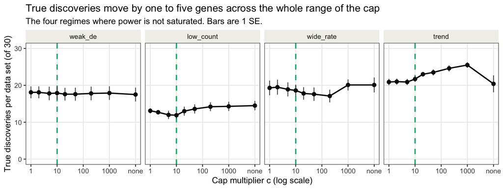

```r
tp_regime_vec <- c("weak_de", "low_count", "wide_rate", "trend")
plot_df <- sweep_plot_df[sweep_plot_df$regime %in% tp_regime_vec, ]
plot_df$regime <- factor(plot_df$regime, levels = tp_regime_vec)

plot1 <- ggplot2::ggplot(plot_df, ggplot2::aes(x = multiplier_plot, y = tp))
plot1 <- plot1 + ggplot2::geom_vline(xintercept = 10,
                                     colour = method_col_vec[["10x cap"]],
                                     linewidth = 0.8, linetype = "dashed")
plot1 <- plot1 + ggplot2::geom_errorbar(ggplot2::aes(ymin = tp - tp_se,
                                                     ymax = tp + tp_se),
                                        width = 0, colour = "#52514e")
plot1 <- plot1 + ggplot2::geom_line(colour = "#0b0b0b", linewidth = 0.8)
plot1 <- plot1 + ggplot2::geom_point(colour = "#0b0b0b", size = 2)
plot1 <- plot1 + ggplot2::facet_wrap(~ regime, nrow = 1)
plot1 <- plot1 + ggplot2::scale_x_log10(breaks = c(1, 10, 100, 1000, 1e4),
                                        labels = c("1", "10", "100", "1000",
                                                   "none"))
plot1 <- plot1 + ggplot2::scale_y_continuous(limits = c(0, 30))
plot1 <- plot1 + ggplot2::labs(x = "Cap multiplier c (log scale)",
                               y = "True discoveries per data set (of 30)",
                               title = "True discoveries move by one to five genes across the whole range of the cap",
                               subtitle = "The four regimes where power is not saturated. Bars are 1 SE.")
plot(plot1)
```

```r
capped_df <- sweep_plot_df[sweep_plot_df$multiplier %in% c(2, 5, 10, 20, 50),
                           c("multiplier", "regime", "frac_capped")]
capped_wide_df <- stats::reshape(capped_df, idvar = "multiplier",
                                 timevar = "regime", direction = "wide")
colnames(capped_wide_df) <- sub("^frac_capped\\.", "",
                                colnames(capped_wide_df))
capped_wide_df <- capped_wide_df[order(capped_wide_df$multiplier),
                                 c("multiplier", "null", "baseline",
                                   "low_count", "wide_rate", "trend",
                                   "near_poisson", "generate_null")]
knitr::kable(capped_wide_df, digits = 2, row.names = FALSE,
             caption = "Fraction of genes whose rate the cap changes, by multiplier c.")
```

Fraction of genes whose rate the cap changes, by multiplier c.

| multiplier | null | baseline | low_count | wide_rate | trend | near_poisson | generate_null |
| --- | --- | --- | --- | --- | --- | --- | --- |
| 2 | 0.97 | 0.97 | 0.98 | 0.80 | 0.90 | 1.00 | 0.31 |
| 5 | 0.42 | 0.41 | 0.55 | 0.64 | 0.67 | 1.00 | 0.16 |
| 10 | 0.12 | 0.11 | 0.22 | 0.49 | 0.45 | 0.95 | 0.07 |
| 20 | 0.03 | 0.03 | 0.09 | 0.34 | 0.28 | 0.80 | 0.03 |
| 50 | 0.01 | 0.01 | 0.05 | 0.23 | 0.17 | 0.62 | 0.02 |

What the sweep shows:

- **Between $c = 5$ and $c = 20$ the choice matters little** for false discoveries. Beyond 50 they rise in every regime.
- **Too tight a cap is also worse when the rate depends on expression.** In `trend`, $c = 1$ and $c = 2$ give 3.5 and 2.8 false discoveries against 1.0 at $c = 10$. `master`’s bound is in that tight range.
- **At $c = 10$ most genes keep their own estimate** in ordinary data. At `master`’s bound almost none do.
- **True discoveries change little, and not always in the cap’s favor.** In `low_count` they are lowest near $c = 10$ (11.9, SE 1.0) and higher at $c = 1$ (13.1) and with no cap (14.5, which comes with 8.5 false discoveries). The differences at the tight end are about one standard error.

## 5.5 Why not a cap taken from the literature

Every package in the wiki bounds its dispersion, so a bound is ordinary practice.

| Package | Bound, as implemented | In this report’s terms | Wiki |
| --- | --- | --- | --- |
| DESeq2 | `minDisp = 1e-8`; `maxDisp <- max(10, ncol(object))` | $\theta \le 10^8$ | `pkg-deseq2`, `R/core.R` L714–729 |
| nebula | `max` default `c(10, 1000)` for $(\sigma^2, \phi)$ | cell-level $\theta \le 1000$ | `pkg-nebula`, `R/nebula.R` L14–15 |
| glmpca | $\theta$ capped at $10^4$ | $\theta \le 10^4$ | `pkg-glmpca` |

Those bounds are numerical guards. The measured level of technical overdispersion in UMI data gives a bound with a meaning:

- *“negative control data were consistent with overdispersion θ ≈ 100 or larger”*. Lause, Berens and Kobak (2021), Results, p.6. (wiki: `lause-2021`)
- *“measurement dispersion is no larger than 5 × 10⁻³”*, that is $\theta \ge 200$. Sarkar and Stephens (2021), Results, p.11. (wiki: `sarkar-stephens-2021`, `technical-vs-biological-variance`)

Since $\theta = \mu\beta$ and the fitted $\mu$ is about 1, “no gene is less overdispersed than the measurement itself” would be a cap near $\beta = 100$ to $200$. With a median library size of about 2 in these simulations that is $c = 50$ to $100$. **At $c = 50$ the false discoveries under the null are 1.2, against 0.2 at $c = 10$.** The cap that calibrates this test is tighter than what the literature on technical noise supports. The documentation should therefore describe it as a bound on the weight the posterior gives to the fit, and not as an estimate of a floor on overdispersion.

# 6 In what sense it improves on `master`

## 6.1 As an estimate of the rate

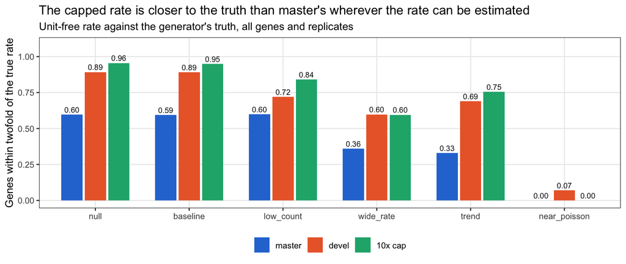

```r
acc_regime_vec <- c("null", "baseline", "low_count", "wide_rate", "trend",
                    "near_poisson")
plot_df <- accuracy_df[accuracy_df$candidate %in% names(method_label_vec) &
                         accuracy_df$regime %in% acc_regime_vec, ]
plot_df$method <- .label_method(plot_df$candidate)
plot_df$regime <- factor(plot_df$regime, levels = acc_regime_vec)

plot1 <- ggplot2::ggplot(plot_df, ggplot2::aes(x = regime,
                                               y = frac_within_2fold,
                                               fill = method))
plot1 <- plot1 + ggplot2::geom_col(position = ggplot2::position_dodge(width = 0.75),
                                   width = 0.68)
plot1 <- plot1 + ggplot2::geom_text(ggplot2::aes(label = sprintf("%.2f", frac_within_2fold)),
                                    position = ggplot2::position_dodge(width = 0.75),
                                    vjust = -0.4, size = 2.8,
                                    colour = "#0b0b0b")
plot1 <- plot1 + ggplot2::scale_y_continuous(limits = c(0, 1.08),
                                             breaks = seq(0, 1, by = 0.25))
plot1 <- plot1 + ggplot2::scale_fill_manual(values = method_col_vec,
                                            name = NULL)
plot1 <- plot1 + ggplot2::labs(x = NULL,
                               y = "Genes within twofold of the true rate",
                               title = "The capped rate is closer to the truth than master's wherever the rate can be estimated",
                               subtitle = "Unit-free rate against the generator's truth, all genes and replicates")
plot(plot1)
```

```r
acc_df <- accuracy_df[accuracy_df$candidate %in% names(method_label_vec) &
                        accuracy_df$regime %in% acc_regime_vec,
                      c("candidate", "regime", "spearman", "median_ratio")]
acc_df$method <- as.character(.label_method(acc_df$candidate))
acc_wide_df <- stats::reshape(acc_df[, c("method", "regime", "spearman",
                                         "median_ratio")],
                              idvar = "regime", timevar = "method",
                              direction = "wide")
acc_wide_df <- acc_wide_df[match(acc_regime_vec, acc_wide_df$regime),
                           c("regime", "spearman.master", "spearman.devel",
                             "spearman.10x cap", "median_ratio.master",
                             "median_ratio.devel", "median_ratio.10x cap")]
knitr::kable(acc_wide_df, digits = 2, row.names = FALSE,
             col.names = c("Regime", "Spearman: master", "devel", "10x cap",
                           "Median estimate / truth: master", "devel",
                           "10x cap"),
             caption = "Rank agreement with the truth within a data set, and the median ratio to the truth.")
```

Rank agreement with the truth within a data set, and the median ratio to the truth.

| Regime | Spearman: master | devel | 10x cap | Median estimate / truth: master | devel | 10x cap |
| --- | --- | --- | --- | --- | --- | --- |
| null | 0.05 | 0.77 | 0.77 | 0.57 | 1.14 | 1.14 |
| baseline | 0.08 | 0.77 | 0.77 | 0.57 | 1.13 | 1.13 |
| low_count | 0.02 | 0.64 | 0.64 | 0.59 | 1.41 | 1.35 |
| wide_rate | 0.46 | 0.88 | 0.86 | 0.22 | 1.12 | 0.78 |
| trend | -0.02 | 0.84 | 0.82 | 0.27 | 1.21 | 0.87 |
| near_poisson | -0.01 | 0.08 | 0.03 | 0.01 | 2.08 | 0.04 |

- **Where the rate can be estimated, the cap inherits `devel`’s accuracy.** Its Spearman correlation with the truth equals `devel`’s, and more genes are within twofold than under `devel`, because the boundary genes are no longer at $10^7$.
- **`near_poisson` is the exception, for every method.** The true unit-free rates there are 50 to 1000. `master` returns about 2.5 and the cap returns
  10. Neither is an estimate. The data do not contain the information: even the genes with a finite `devel` estimate gain a median of 0.26 log-likelihood units over Poisson.

## 6.2 As an input to the test

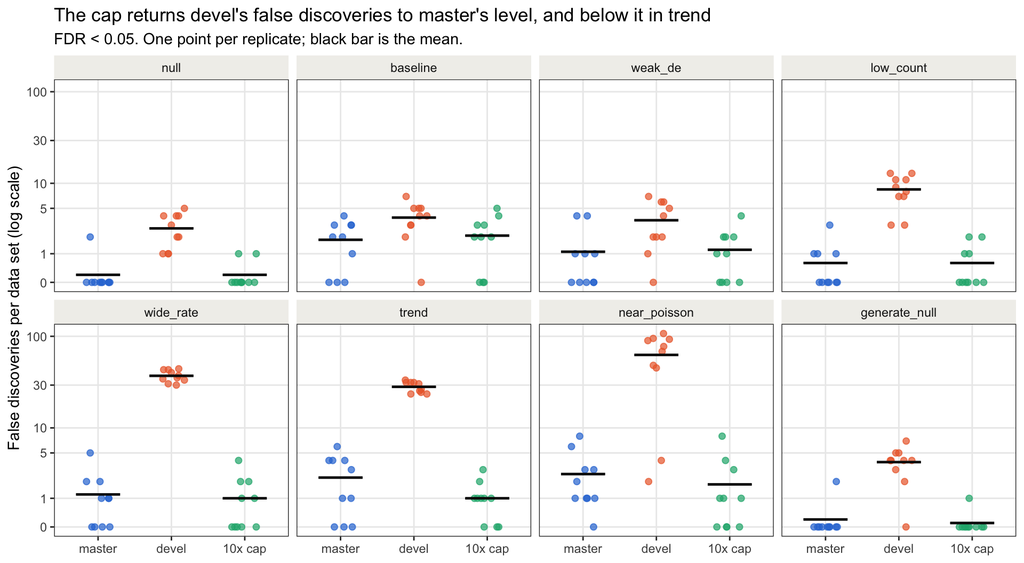

```r
plot_df <- by_rep_df
plot_df$method <- .label_method(plot_df$candidate)
plot_df$regime <- factor(plot_df$regime, levels = regime_vec)
mean_df <- stats::aggregate(fp ~ method + regime, data = plot_df, FUN = mean)

plot1 <- ggplot2::ggplot(plot_df, ggplot2::aes(x = method, y = fp + 1))
plot1 <- plot1 + ggplot2::geom_point(ggplot2::aes(colour = method),
                                     position = ggplot2::position_jitter(width = 0.18,
                                                                         height = 0,
                                                                         seed = 1),
                                     size = 1.8, alpha = 0.7)
plot1 <- plot1 + ggplot2::geom_errorbar(data = mean_df,
                                        ggplot2::aes(ymin = fp + 1,
                                                     ymax = fp + 1),
                                        width = 0.6, colour = "#0b0b0b",
                                        linewidth = 0.8)
plot1 <- plot1 + ggplot2::facet_wrap(~ regime, nrow = 2)
plot1 <- plot1 + ggplot2::scale_y_log10(breaks = c(1, 2, 6, 11, 31, 101),
                                        labels = c("0", "1", "5", "10", "30",
                                                   "100"))
plot1 <- plot1 + ggplot2::scale_colour_manual(values = method_col_vec,
                                              guide = "none")
plot1 <- plot1 + ggplot2::labs(x = NULL,
                               y = "False discoveries per data set (log scale)",
                               title = "The cap returns devel's false discoveries to master's level, and below it in trend",
                               subtitle = "FDR < 0.05. One point per replicate; black bar is the mean.")
plot(plot1)
```

```r
disc_df <- discovery_df[discovery_df$candidate %in% names(method_label_vec),
                        c("candidate", "regime", "fp", "tp", "type1", "auc")]
disc_df$method <- as.character(.label_method(disc_df$candidate))
num_de_df <- unique(by_rep_df[, c("regime", "num_de")])
disc_table_df <- do.call(rbind, lapply(regime_vec, function(regime){
  x <- disc_df[disc_df$regime == regime, ]
  x <- x[match(method_label_vec, x$method), ]
  data.frame(regime = regime,
             num_de = num_de_df$num_de[num_de_df$regime == regime][1],
             fp = paste0(.fmt(x$fp), collapse = " / "),
             tp = paste0(.fmt(x$tp), collapse = " / "),
             type1 = paste0(.fmt(x$type1, 3), collapse = " / "),
             auc = paste0(ifelse(is.na(x$auc), "--", .fmt(x$auc, 3)),
                          collapse = " / "))
}))
knitr::kable(disc_table_df, row.names = FALSE,
             col.names = c("Regime", "DE genes", "False discoveries",
                           "True discoveries", "Type-I error at p < 0.05",
                           "AUC of |z|"),
             caption = "Each cell is master / devel / 10x cap. Means over 10 replicates of 300 genes.")
```

Each cell is master / devel / 10x cap. Means over 10 replicates of 300 genes.

| Regime | DE genes | False discoveries | True discoveries | Type-I error at p < 0.05 | AUC of \|z\| |
| --- | --- | --- | --- | --- | --- |
| null | 0 | 0.2 / 2.7 / 0.2 | 0.0 / 0.0 / 0.0 | 0.048 / 0.062 / 0.053 | – / – / – |
| baseline | 15 | 1.8 / 3.8 / 2.1 | 15.0 / 15.0 / 15.0 | 0.054 / 0.055 / 0.052 | 1.000 / 0.998 / 1.000 |
| weak_de | 30 | 1.1 / 3.5 / 1.2 | 18.2 / 17.5 / 17.9 | 0.042 / 0.048 / 0.041 | 0.978 / 0.968 / 0.975 |
| low_count | 30 | 0.6 / 8.5 / 0.6 | 12.3 / 14.5 / 11.9 | 0.036 / 0.075 / 0.037 | 0.946 / 0.919 / 0.944 |
| wide_rate | 30 | 1.2 / 37.8 / 1.0 | 18.9 / 20.1 / 18.6 | 0.037 / 0.165 / 0.041 | 0.979 / 0.870 / 0.976 |
| trend | 30 | 2.3 / 28.7 / 1.0 | 20.7 / 20.4 / 21.7 | 0.056 / 0.131 / 0.044 | 0.954 / 0.891 / 0.965 |
| near_poisson | 15 | 2.6 / 63.3 / 1.8 | 15.0 / 12.7 / 15.0 | 0.067 / 0.276 / 0.065 | 1.000 / 0.881 / 1.000 |
| generate_null | 10 | 0.2 / 3.8 / 0.1 | 8.8 / 8.2 / 8.1 | 0.039 / 0.053 / 0.034 | 0.997 / 0.987 / 0.996 |

- **Against `devel`**, the cap removes the inflation in every regime.
- **Against `master`**, the table below takes the difference within each replicate, which removes the variation between data sets. The cap has fewer false discoveries in `trend` and `near_poisson`, and 0.3 more in `baseline`. Each of these is two to three standard errors from zero, and with eight regimes compared one difference of that size is unremarkable. The others are within two standard errors. For true discoveries the cap gains one gene in `trend` and loses 0.7 of a gene under `generate_null()`; the rest are within one standard error.

```r
paired_df <- merge(by_rep_df[by_rep_df$candidate == "cap_10s",
                             c("regime", "rep", "fp", "tp")],
                   by_rep_df[by_rep_df$candidate == "master",
                             c("regime", "rep", "fp", "tp")],
                   by = c("regime", "rep"), suffixes = c("_cap", "_master"))
.mean_se <- function(v){
  paste0(.fmt(mean(v), 2), " (", .fmt(stats::sd(v) / sqrt(length(v)), 2), ")")
}
paired_table_df <- do.call(rbind, lapply(regime_vec, function(regime){
  x <- paired_df[paired_df$regime == regime, ]
  data.frame(regime = regime,
             fp_diff = .mean_se(x$fp_cap - x$fp_master),
             tp_diff = .mean_se(x$tp_cap - x$tp_master))
}))
knitr::kable(paired_table_df, row.names = FALSE,
             col.names = c("Regime",
                           "False discoveries: 10x cap minus master, mean (SE)",
                           "True discoveries: 10x cap minus master, mean (SE)"),
             caption = "Paired over the 10 replicates of each regime. Negative false discoveries and positive true discoveries favor the cap.")
```

Paired over the 10 replicates of each regime. Negative false discoveries and positive true discoveries favor the cap.

| Regime | False discoveries: 10x cap minus master, mean (SE) | True discoveries: 10x cap minus master, mean (SE) |
| --- | --- | --- |
| null | 0.00 (0.15) | 0.00 (0.00) |
| baseline | 0.30 (0.15) | 0.00 (0.00) |
| weak_de | 0.10 (0.41) | -0.30 (0.75) |
| low_count | 0.00 (0.30) | -0.40 (0.96) |
| wide_rate | -0.20 (0.13) | -0.30 (0.70) |
| trend | -1.30 (0.58) | 1.00 (0.45) |
| near_poisson | -0.80 (0.25) | 0.00 (0.00) |
| generate_null | -0.10 (0.23) | -0.70 (0.40) |

- **In `trend` the cap is better than `master` on both counts**, and ranks the genes better (AUC 0.965 against 0.954). Section 7.4 explains why.
- **`devel`’s extra true discoveries in `low_count` and `wide_rate` are not power.** Its ranking of the genes is worse there (AUC 0.919 and 0.870 against 0.944 and 0.976). It rejects more because its threshold is miscalibrated.

## 6.3 Summary of the comparison with `master`

[output not shown]

# 7 The nuances

## 7.1 The rate has units

> **The mistake to avoid.** Comparing `nuisance_vec` with the generator’s $\beta_j$ directly makes `devel` look biased upward two- to threefold. The generator’s library size averages 1. The fit’s library size contains the gene intercept and the covariate effects, so the same overdispersion is $\beta_j \cdot s$ in the fit’s units. The comparison runs without error and gives a plausible wrong answer.

```r
unit_df <- boundary_df[match(c("null", "baseline", "low_count", "wide_rate",
                               "trend"), boundary_df$regime),
                       c("regime", "ratio_raw", "ratio_unit_free",
                         "spearman_raw", "spearman_unit_free")]
knitr::kable(unit_df, digits = 2, row.names = FALSE,
             col.names = c("Regime", "Median devel / truth, raw",
                           "Median devel / truth, unit-free",
                           "Spearman, raw", "Spearman, unit-free"),
             caption = "devel's estimate against the truth, genes with a finite estimate.")
```

devel’s estimate against the truth, genes with a finite estimate.

| Regime | Median devel / truth, raw | Median devel / truth, unit-free | Spearman, raw | Spearman, unit-free |
| --- | --- | --- | --- | --- |
| null | 2.43 | 1.14 | 0.60 | 0.77 |
| baseline | 2.50 | 1.13 | 0.59 | 0.77 |
| low_count | 0.32 | 1.39 | 0.49 | 0.64 |
| wide_rate | 2.04 | 1.03 | 0.85 | 0.88 |
| trend | 1.75 | 1.11 | 0.03 | 0.85 |

**Unit-free, `devel` is 3% to 14% above the truth** (39% at low counts). Section 4.1 of the comparison report and the session-13 notes state the raw figure. A small excess in this direction is what is expected when the fit absorbs part of the residual variance (wiki: `nuisance-parameter-bias`).

## 7.2 The true rates do not calibrate the test when some are very large

Feeding the pipeline the *true* rates is the best any estimator could do.

```r
oracle_table_df <- do.call(rbind, lapply(c("wide_rate", "trend"),
                                         function(regime){
  data.frame(regime = regime,
             fp_oracle = .get(discovery_df, "oracle", regime, "fp"),
             tp_oracle = .get(discovery_df, "oracle", regime, "tp"),
             fp_cap = .get(discovery_df, "cap_10s", regime, "fp"),
             tp_cap = .get(discovery_df, "cap_10s", regime, "tp"))
}))
knitr::kable(oracle_table_df, digits = 1, row.names = FALSE,
             col.names = c("Regime", "True rates: false discoveries",
                           "true discoveries", "10x cap: false discoveries",
                           "true discoveries"),
             caption = "Per data set, 30 DE genes.")
```

Per data set, 30 DE genes.

| Regime | True rates: false discoveries | true discoveries | 10x cap: false discoveries | true discoveries |
| --- | --- | --- | --- | --- |
| wide_rate | 5.7 | 16.6 | 1 | 18.6 |
| trend | 1.5 | 24.3 | 1 | 21.7 |

```r
knitr::kable(oracle_rate_df, digits = c(0, 0, 0, 0, 4, 2), row.names = FALSE,
             col.names = c("Regime", "True unit-free rate", "Null genes",
                           "False discoveries", "Fraction",
                           "SD of the null statistic"),
             caption = "The true rates' false discoveries, by the size of the true rate. All replicates pooled.")
```

The true rates’ false discoveries, by the size of the true rate. All replicates pooled.

| Regime | True unit-free rate | Null genes | False discoveries | Fraction | SD of the null statistic |
| --- | --- | --- | --- | --- | --- |
| trend | below 10 | 1509 | 3 | 0.0020 | 0.35 |
| trend | 10 to 30 | 1050 | 4 | 0.0038 | 0.38 |
| trend | 30 to 100 | 141 | 8 | 0.0567 | 0.51 |
| wide_rate | below 10 | 1346 | 0 | 0.0000 | 0.30 |
| wide_rate | 10 to 30 | 508 | 2 | 0.0039 | 0.37 |
| wide_rate | 30 to 100 | 527 | 17 | 0.0323 | 0.50 |
| wide_rate | above 100 | 319 | 38 | 0.1191 | 0.70 |

- **With true rates below about 30, the truth works** and is the most powerful choice (`trend`).
- **With true rates above 30 it does not.** The null statistics of those genes are 1.5 to 2.3 times wider than the rest, for the reason of section 2.3. In `wide_rate` they supply 55 of the 57 false discoveries. In `trend` they are 5% of the null genes and supply 8 of the 15.

**The earlier statement in the brainstorm that “the true rates do not calibrate the test” was too general.** It holds for genes that are nearly Poisson in truth. Those genes are the ones the cap acts on.

## 7.3 More cells

The boundary is a small-sample effect for genes with moderate rates. The problem of section 7.2 is not.

```r
cells_candidate_vec <- c("mle", "cap_max_s", "cap_10s", "oracle")
cells_label_vec <- c(mle = "devel", cap_max_s = "master's bound",
                     cap_10s = "10x cap", oracle = "true rates")
cells_df <- more_cells_df[more_cells_df$candidate %in% cells_candidate_vec, ]
cells_table_df <- do.call(rbind, lapply(cells_candidate_vec, function(candidate){
  x <- cells_df[cells_df$candidate == candidate, ]
  x <- x[match(c("null", "weak_de", "wide_rate"), x$regime), ]
  data.frame(method = cells_label_vec[[candidate]],
             null = .fmt(x$fp[1]),
             weak_de = paste0(.fmt(x$fp[2]), " / ", .fmt(x$tp[2])),
             wide_rate = paste0(.fmt(x$fp[3]), " / ", .fmt(x$tp[3])))
}))
knitr::kable(cells_table_df, row.names = FALSE,
             col.names = c("Rates", "null: false discoveries",
                           "weak_de: false / true",
                           "wide_rate: false / true"),
             caption = "150 cells per individual (3000 cells) in place of 30. master itself was not run at this size; its bound is applied to devel's estimate.")
```

150 cells per individual (3000 cells) in place of 30. master itself was not run at this size; its bound is applied to devel’s estimate.

| Rates | null: false discoveries | weak_de: false / true | wide_rate: false / true |
| --- | --- | --- | --- |
| devel | 0.6 | 3.3 / 29.4 | 20.1 / 26.7 |
| master’s bound | 0.4 | 2.9 / 29.2 | 3.2 / 29.3 |
| 10x cap | 0.5 | 3.2 / 29.4 | 3.0 / 28.5 |
| true rates | 0.6 | 3.2 / 29.6 | 10.1 / 27.3 |

- **With true rates of 2 to 8 and 3000 cells, no gene is at the boundary and `devel` needs no fix.**
- **With widely spread true rates the inflation remains**, and the cap still removes it. 5.8% of genes are still at the boundary, against 16.0% at 600 cells.
- Methods whose strength depends on the precision of the estimate (empirical-Bayes shrinkage, the profile-likelihood bound) weaken as cells are added: 6.2 and 5.7 false discoveries in `wide_rate` against the cap’s 3.0. The cap does not depend on the number of cells. This was the reason for choosing it.

## 7.4 A real trend between overdispersion and expression

No other regime ties the rate to the gene’s expression, so `trend` was written for this report. It uses DESeq2’s parametric trend, $\alpha(m) = \alpha_0 + \alpha_1/m$ in the $\text{Var} = m + \alpha m^2$ form (wiki: `trended-dispersion`, `pkg-deseq2`; `parametricDispersionFit` in `R/core.R` returns `coefs[1] + coefs[2] / q`). With $\theta = \mu\beta$ this is, in the generator’s units,

$$\beta_j = \frac{1}{\alpha_0\, e^{\text{intercept}_j} + \alpha_1}\cdot
e^{\varepsilon_j},
\qquad \alpha_0 = 0.1,\ \ \alpha_1 = 0.02,\ \ \varepsilon_j \sim N(0,
0.3^2),$$

with gene intercepts from −2 to 2. **Highly expressed genes are more overdispersed relative to Poisson, and lowly expressed genes are nearly Poisson.** $\alpha_0 = 0.1$ is the plateau $\theta \approx 10$ that Lause, Berens and Kobak report in PBMC data and read as biological (Results, p.6; wiki: `lause-2021`). $\alpha_1$ and the noise are my choices.

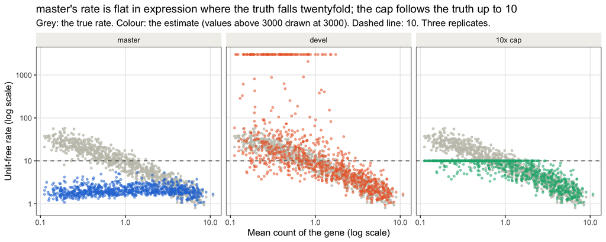

```r
plot_df <- rate_df[rate_df$regime == "trend", ]
plot_df$method <- .label_method(plot_df$candidate)
plot_df$rate_plot <- pmin(plot_df$rate_unit_free, 3000)

plot1 <- ggplot2::ggplot(plot_df, ggplot2::aes(x = mean_count))
plot1 <- plot1 + ggplot2::geom_point(ggplot2::aes(y = nuisance_true),
                                     colour = "#c3c2b7", size = 0.9,
                                     alpha = 0.7)
plot1 <- plot1 + ggplot2::geom_hline(yintercept = 10, colour = "#52514e",
                                     linewidth = 0.5, linetype = "dashed")
plot1 <- plot1 + ggplot2::geom_point(ggplot2::aes(y = rate_plot,
                                                  colour = method),
                                     size = 0.9, alpha = 0.5)
plot1 <- plot1 + ggplot2::facet_wrap(~ method, nrow = 1)
plot1 <- plot1 + ggplot2::scale_x_log10()
plot1 <- plot1 + ggplot2::scale_y_log10()
plot1 <- plot1 + ggplot2::scale_colour_manual(values = method_col_vec,
                                              guide = "none")
plot1 <- plot1 + ggplot2::labs(x = "Mean count of the gene (log scale)",
                               y = "Unit-free rate (log scale)",
                               title = "master's rate is flat in expression where the truth falls twentyfold; the cap follows the truth up to 10",
                               subtitle = "Grey: the true rate. Colour: the estimate (values above 3000 drawn at 3000). Dashed line: 10. Three replicates.")
plot(plot1)
```

```r
third_df <- trend_third_df
third_df$third <- factor(third_df$third, levels = c("low", "middle", "high"))
third_label_vec <- c(master = "master", mle = "devel", cap_10s = "10x cap",
                     oracle = "true rates")
third_df$method <- factor(third_label_vec[third_df$candidate],
                          levels = third_label_vec)
third_df <- third_df[order(third_df$third, third_df$method), ]
knitr::kable(third_df[, c("third", "mean_count", "rate_true_median", "method",
                          "fp", "tp", "num_de", "frac_within_2fold")],
             digits = c(0, 2, 1, 0, 1, 1, 1, 2), row.names = FALSE,
             col.names = c("Third of genes by expression", "Median mean count",
                           "Median true rate", "Rates", "False discoveries",
                           "True discoveries", "DE genes",
                           "Within twofold of the truth"),
             caption = "The trend regime, by third of the genes' expression. Per data set.")
```

The trend regime, by third of the genes’ expression. Per data set.

| Third of genes by expression | Median mean count | Median true rate | Rates | False discoveries | True discoveries | DE genes | Within twofold of the truth |
| --- | --- | --- | --- | --- | --- | --- | --- |
| low | 0.28 | 21.2 | master | 0.0 | 2.3 | 10.7 | 0.00 |
| low | 0.28 | 21.2 | devel | 21.5 | 5.8 | 10.7 | 0.42 |
| low | 0.28 | 21.2 | 10x cap | 0.0 | 3.0 | 10.7 | 0.38 |
| low | 0.28 | 21.2 | true rates | 1.1 | 5.9 | 10.7 | 1.00 |
| middle | 1.06 | 8.2 | master | 0.2 | 8.9 | 9.8 | 0.13 |
| middle | 1.06 | 8.2 | devel | 5.7 | 6.4 | 9.8 | 0.72 |
| middle | 1.06 | 8.2 | 10x cap | 0.2 | 9.2 | 9.8 | 0.93 |
| middle | 1.06 | 8.2 | true rates | 0.1 | 8.9 | 9.8 | 1.00 |
| high | 4.18 | 2.4 | master | 2.1 | 9.5 | 9.5 | 0.86 |
| high | 4.18 | 2.4 | devel | 1.5 | 8.2 | 9.5 | 0.94 |
| high | 4.18 | 2.4 | 10x cap | 0.8 | 9.5 | 9.5 | 0.95 |
| high | 4.18 | 2.4 | true rates | 0.3 | 9.5 | 9.5 | 1.00 |

What `trend` shows:

- **`master`’s bound has the wrong shape.** It is a multiple of the library size for nearly every gene, so its unit-free rate is about constant, while the truth falls twentyfold across the range. 33% of `master`’s rates are within twofold of the truth, against 75% for the cap.
- **That costs `master` false discoveries among the highly expressed genes.** They are truly the most overdispersed, and a rate that is the same for every gene is too large for them *relative to the others*, which is what reaches the posterior after the rescaling (section 7.5). The high third supplies 2.1 of `master`’s 2.3 false discoveries. It also costs power in the low and middle thirds.
- **The cap’s cost is in the low third.** Those genes have a true rate near 20, the cap holds them at 10, and the test is more cautious than it need be: 3.0 true discoveries against 5.9 with the true rates. It is still above `master`’s 2.3.
- **`devel` fails here as in `wide_rate`**: 12% of genes are at the boundary, mostly among the lowly expressed genes (figure above), and its false discoveries follow them: 21.5 of 28.7 are in the low third.

**Would modelling the trend do better?** Shrinking toward a fitted trend in expression, as DESeq2 does, was tried on the empirical-Bayes prototype.

```r
variant_label_vec <- c(eb_map = "shrinkage, constant centre",
                       eb_trend = "shrinkage, centre is a fitted trend")
variant_table_df <- do.call(rbind, lapply(names(variant_label_vec),
                                          function(candidate){
  data.frame(method = variant_label_vec[[candidate]],
             fp = .get(variant_df, candidate, "trend", "fp"),
             fp_se = .get(variant_df, candidate, "trend", "fp_se"),
             tp = .get(variant_df, candidate, "trend", "tp"),
             slope = .get(variant_df, candidate, "trend", "slope"),
             within = .get(accuracy_df, candidate, "trend",
                           "frac_within_2fold"),
             spearman = .get(accuracy_df, candidate, "trend", "spearman"))
}))
cap_row_df <- data.frame(method = "10x cap",
                         fp = .get(discovery_df, "cap_10s", "trend", "fp"),
                         fp_se = .get(sweep_df, "cap_10", "trend", "fp_se"),
                         tp = .get(discovery_df, "cap_10s", "trend", "tp"),
                         slope = NA,
                         within = .get(accuracy_df, "cap_10s", "trend",
                                       "frac_within_2fold"),
                         spearman = .get(accuracy_df, "cap_10s", "trend",
                                         "spearman"))
knitr::kable(rbind(cap_row_df, variant_table_df), digits = 2,
             row.names = FALSE,
             col.names = c("Rates", "False discoveries", "SE",
                           "True discoveries", "Fitted slope",
                           "Within twofold of the truth",
                           "Spearman with the truth"),
             caption = "The trend regime, 600 cells. The slope is of the log unit-free rate on the log mean count.")
```

The trend regime, 600 cells. The slope is of the log unit-free rate on the log mean count.

| Rates | False discoveries | SE | True discoveries | Fitted slope | Within twofold of the truth | Spearman with the truth |
| --- | --- | --- | --- | --- | --- | --- |
| 10x cap | 1.0 | 0.30 | 21.7 | NA | 0.75 | 0.82 |
| shrinkage, constant centre | 1.0 | 0.26 | 22.7 | 0.00 | 0.85 | 0.83 |
| shrinkage, centre is a fitted trend | 1.6 | 0.60 | 24.3 | -0.76 | 0.97 | 0.95 |

- **When a trend exists, a prior centred on it gives the most accurate rates and the most true discoveries**, with false discoveries within noise of the cap’s. This is a real advantage, and the cap leaves it unused.
- **It was not chosen because its protection depends on the number of cells** (section 7.3), and because the wiki records two cautions about fitted trends. One is that a trend can be produced by the estimator alone: Lause, Berens and Kobak simulated one constant $\theta$ and the estimation procedure *“showed the same positive correlation of θ̂_g with the average expression as in real data”* (Results, p.5). The other is the wiki’s own observation (`trended-dispersion`) that the assumption that genes of similar expression have similar dispersion is “rarely stated explicitly and, as far as the ingested sources go, never justified.”
- Whether real data have a trend in the eSVD model’s rate is not known. The trend with a cap as a backstop is a candidate for a later version.

## 7.5 The rescaling by the geometric mean

```r
rescale_table_df <- rescale_df
rescale_table_df$method <- .label_method(rescale_table_df$candidate)
rescale_table_df$rescaled <- ifelse(rescale_table_df$geometric_mean > 1,
                                    "yes", "no")
rescale_table_df <- rescale_table_df[order(match(rescale_table_df$regime,
                                                 regime_vec),
                                           rescale_table_df$method), ]
rescale_table_df <- rescale_table_df[rescale_table_df$regime %in%
                                       c("baseline", "low_count", "trend",
                                         "near_poisson", "generate_null"), ]
# Columns that run from 0.001 to millions are printed to two significant
# digits.
for(column in c("geometric_mean", "rescaled_q01", "rescaled_q50",
                "rescaled_q99")){
  rescale_table_df[[column]] <- format(signif(rescale_table_df[[column]], 2),
                                       scientific = FALSE, drop0trailing = TRUE,
                                       trim = TRUE, big.mark = ",")
}
knitr::kable(rescale_table_df[, c("regime", "method", "geometric_mean",
                                  "rescaled", "rescaled_q01", "rescaled_q50",
                                  "rescaled_q99")],
             row.names = FALSE, align = "llrlrrr",
             col.names = c("Regime", "Rates", "Geometric mean of the rates",
                           "Rescaled?", "Rate / geometric mean: 1st percentile",
                           "median", "99th percentile"),
             caption = "bool_stabilize_underdispersion divides every rate by the geometric mean when it exceeds 1. Means over replicates; the percentiles pool all genes.")
```

bool_stabilize_underdispersion divides every rate by the geometric mean when it exceeds 1. Means over replicates; the percentiles pool all genes.

| Regime | Rates | Geometric mean of the rates | Rescaled? | Rate / geometric mean: 1st percentile | median | 99th percentile |
| --- | --- | --- | --- | --- | --- | --- |
| baseline | master | 4.7 | yes | 0.36 | 0.99 | 3.1 |
| baseline | devel | 11 | yes | 0.21 | 0.89 | 11 |
| baseline | 10x cap | 9.6 | yes | 0.24 | 1 | 4 |
| low_count | master | 0.49 | no | 0.22 | 1 | 4.2 |
| low_count | devel | 1.8 | yes | 0.1 | 0.7 | 1,500,000 |
| low_count | 10x cap | 1.1 | yes | 0.17 | 1 | 4.9 |
| trend | master | 2.1 | yes | 0.096 | 1.1 | 7.7 |
| trend | devel | 41 | yes | 0.03 | 0.26 | 250,000 |
| trend | 10x cap | 5.9 | yes | 0.19 | 1.1 | 4.6 |
| near_poisson | master | 5 | yes | 0.35 | 1 | 3.2 |
| near_poisson | devel | 19,000 | yes | 0.00057 | 0.042 | 1,800 |
| near_poisson | 10x cap | 21 | yes | 0.42 | 1 | 2.3 |
| generate_null | master | 0.39 | no | 0.025 | 1.4 | 15 |
| generate_null | devel | 0.71 | no | 0.014 | 1.1 | 150 |
| generate_null | 10x cap | 0.61 | no | 0.016 | 1.2 | 27 |

- **Where the rescaling applies, the level of the rates is discarded.** In `baseline` the three versions have geometric means of 4.7, 11 and 9.6, and after the division all three are centred at 1. What differs between them is the spread.
- **This is why the cap matters through the spread and not the level.** Under `devel` in `near_poisson` the geometric mean is about 1.9e+04. After the division the boundary genes are in the thousands and the median gene is at 0.04: two populations, one collapsed onto the fit and one equal to the raw counts.
- **It does not apply in every regime.** Under `generate_null()` all three geometric means are below 1, and under `master` so is `low_count`’s. **The brainstorm’s statement that the rescaling happened in every regime was wrong for these**, and has been corrected there.
- **Between the 1st and the 99th percentile, the rates after the division span a factor of 5 to 30 with the cap, 9 to 80 under `master`, and 50 to several million under `devel`** (eSVD-model regimes of the table).

# 8 What was decided, and what remains open

**Decided (Kevin, 2026-09-29) and shipped in 1.2.0**: the cap $\min\{\hat\beta^{\text{MLE}}_j,\ 10\cdot m_j\}$, with the three details of section 5.1. Here is what became of each part of the recommendation this report made before the decision.

1. **Where.** In R, in `.apply_nuisance_cap()`, called from `estimate_nuisance()` and `recompute_pvalue()`. Not in `src/gamma_rate.cpp`. `compute_test_per_gene()` needed no change, because it reads the capped rate from the fit.
2. **Interface.** `cap_multiplier = 10` in both `estimate_nuisance()` methods and in `eSVD()`, passed on by `eSVD_helper()`; `Inf` gives 1.1.0. A setting that reproduces `master`’s bound was not added; the documentation says `cap_multiplier = 1` is close to it.
3. **Record what the cap did.** Done, as `nuisance_status` with a fourth level, `failed` (section 5.3). The standard error of the fold change under the cap was then measured in the rerun of `../version_comparison/`. The ±2 SE interval covers the truth for at least 99% of genes of every status in five of six regimes. The exception is `strong_de`, and its cause is the depth adjustment, not the rate.
4. **Document it for what it is.** Done in `?estimate_nuisance` and `NEWS.md`: a calibration device, not an estimate of the smallest overdispersion in the data.
5. **Run one of the paper’s data sets.** **Still open.** It needs a path for `PAPER_DATA`. It would record:
   - the fraction of genes at the boundary, above `master`’s bound and above the cap;
   - how far the list of genes at FDR < 0.05 moves between `master` and 1.2.0.

   This is the one check the default $c = 10$ has not had.
6. **Tests.** Written with the change: `UNIT_TEST_PLAN.md` §2.19 to §2.21 (T-CAP, T-REDO, T-DIAG), 54 `test_that` blocks.

**Not adopted**:

- empirical-Bayes shrinkage alone;
- the profile-likelihood bound alone;
- one rate for all genes;
- changes to the test statistic.

The brainstorm gives the result for each. Shrinkage toward a fitted trend, with the cap as a backstop, remains a candidate for a later version if real data show a trend (section 7.4).

# 9 What we glossed over

# 10 References

Wiki page names are in backticks. DOIs were checked against Crossref on 2026-09-29.

- Choudhary, S. and Satija, R. (2022). Comparison and evaluation of statistical error models for scRNA-seq. *Genome Biology* 23:27. [doi:10.1186/s13059-021-02584-9](https://doi.org/10.1186/s13059-021-02584-9). `choudhary-2022`
- Dai, H., Bao, Y. and Bao, M. (2013). Maximum likelihood estimate for the dispersion parameter of the negative binomial distribution. *Statistics & Probability Letters* 83:21–27. [doi:10.1016/j.spl.2012.08.017](https://doi.org/10.1016/j.spl.2012.08.017). `dai-2012`
- He, L. et al. (2021). NEBULA is a fast negative binomial mixed model for differential or co-expression analysis of large-scale multi-subject single-cell data. *Communications Biology* 4. [doi:10.1038/s42003-021-02146-6](https://doi.org/10.1038/s42003-021-02146-6). `he-2021`, `pkg-nebula`
- Lause, J., Berens, P. and Kobak, D. (2021). Analytic Pearson residuals for normalization of single-cell RNA-seq UMI data. *Genome Biology* 22:258. [doi:10.1186/s13059-021-02451-7](https://doi.org/10.1186/s13059-021-02451-7). `lause-2021`
- Law, C. W., Chen, Y., Shi, W. and Smyth, G. K. (2014). voom: precision weights unlock linear model analysis tools for RNA-seq read counts. *Genome Biology* 15:R29. [doi:10.1186/gb-2014-15-2-r29](https://doi.org/10.1186/gb-2014-15-2-r29). `law-2014`
- Lin, K. Z., Qiu, Y. and Roeder, K. (2024). eSVD-DE: cohort-wide differential expression in single-cell RNA-seq data using exponential-family embeddings. *BMC Bioinformatics* 25:113. [doi:10.1186/s12859-024-05724-7](https://doi.org/10.1186/s12859-024-05724-7)
- Love, M. I., Huber, W. and Anders, S. (2014). Moderated estimation of fold change and dispersion for RNA-seq data with DESeq2. *Genome Biology* 15:550. [doi:10.1186/s13059-014-0550-8](https://doi.org/10.1186/s13059-014-0550-8). `love-2014`, `pkg-deseq2`
- Piegorsch, W. W. (1990). Maximum likelihood estimation for the negative binomial dispersion parameter. *Biometrics* 46(3):863–867. [doi:10.2307/2532104](https://doi.org/10.2307/2532104). `piegorsch-1990`
- Sarkar, A. and Stephens, M. (2021). Separating measurement and expression models clarifies confusion in single-cell RNA sequencing analysis. *Nature Genetics* 53(6):770–777. [doi:10.1038/s41588-021-00873-4](https://doi.org/10.1038/s41588-021-00873-4). `sarkar-stephens-2021`
- Svensson, V. (2025). Negative binomial regression and inference using a pre-trained transformer. Preprint, Tahoe Therapeutics (no DOI recorded in the wiki). `svensson-2025`
- Wiki synthesis pages quoted: `underdispersion`, `test-calibration-and-dispersion`, `trended-dispersion`. Also consulted: `dispersion-parameterizations`, `maximum-likelihood-dispersion`, `identifiability-of-dispersion-at-low-counts`, `nuisance-parameter-bias`, `technical-vs-biological-variance`, `pkg-glmpca`.